# report

Dmitry

25 12 2020

Устанавливаем пакеты

```r
chooseCRANmirror(graphics=FALSE, ind=1)

if (!requireNamespace("BiocManager", quietly = TRUE))
  install.packages("BiocManager")

BiocManager::install("edgeR")
BiocManager::install("limma")
install.packages('plyr', repos = "http://cran.us.r-project.org")
install.packages("dplyr")
install.packages("ggplot2")
BiocManager::install("biomaRt")
BiocManager::install("GO.db")
BiocManager::install("org.Hs.eg.db")
```

Подключаем нужные библиотеки

```r
library("org.Hs.eg.db")
library("GO.db")
```

```r
library("ggplot2")
library("limma")
library("biomaRt")
library("plyr")
library("dplyr")
library("edgeR")
```

Данные для анализа: Transcription profiling by high throughput sequencing in basal airway cells of smokers and non-smokers Ссылка: https://www.ebi.ac.uk/gxa/experiments/E-GEOD-47718/

Загружаем данные

```r
origin_table <- read.table("data/E-GEOD-47718-raw-counts.tsv", sep="\t", header=TRUE)
design_table <- read.table("data/E-GEOD-47718-experiment-design.tsv", sep="\t", header=TRUE)
counts_table <- origin_table

col_for_research = "Sample.Characteristic.clinical.information."
```

Таблица каунтов:

```r
head(origin_table)
```

|  | Gene.ID | Gene.Name | SRR886603 | SRR886600 | SRR886569 | SRR886566 | SRR886582 | SRR886606 | SRR886593 | SRR886586 | SRR886565 | SRR886607 | SRR886615 | SRR886577 | SRR886602 | SRR886578 | SRR886594 | SRR886567 | SRR886605 | SRR886580 | SRR886587 | SRR886591 | SRR886616 | SRR886579 | SRR886583 | SRR886592 | SRR886584 | SRR886613 | SRR886585 | … |
| --- | --- | --- | --- | --- | --- | --- | --- | --- | --- | --- | --- | --- | --- | --- | --- | --- | --- | --- | --- | --- | --- | --- | --- | --- | --- | --- | --- | --- | --- | --- |
| 1 | ENSG00000000003 | TSPAN6 | 169 | 78 | 163 | 187 | 48 | 143 | 108 | 107 | 208 | 106 | 143 | 143 | 174 | 152 | 29 | 155 | 136 | 128 | 103 | 41 | 123 | 107 | 193 | 120 | 209 | 44 | 167 | … |
| 2 | ENSG00000000005 | TNMD | 0 | 0 | 0 | 0 | 0 | 0 | 0 | 0 | 0 | 0 | 0 | 0 | 0 | 0 | 0 | 0 | 0 | 0 | 0 | 0 | 0 | 0 | 0 | 0 | 0 | 0 | 0 | … |
| 3 | ENSG00000000419 | DPM1 | 296 | 471 | 411 | 387 | 202 | 246 | 426 | 278 | 337 | 222 | 252 | 341 | 293 | 297 | 102 | 298 | 255 | 414 | 287 | 97 | 190 | 259 | 359 | 388 | 357 | 177 | 312 | … |
| 4 | ENSG00000000457 | SCYL3 | 54 | 47 | 67 | 61 | 25 | 52 | 43 | 29 | 49 | 42 | 60 | 65 | 64 | 75 | 14 | 44 | 42 | 50 | 36 | 19 | 48 | 46 | 75 | 43 | 59 | 43 | 54 | … |
| 5 | ENSG00000000460 | C1orf112 | 154 | 13 | 54 | 112 | 5 | 32 | 16 | 11 | 109 | 40 | 98 | 81 | 169 | 85 | 3 | 97 | 30 | 8 | 14 | 17 | 75 | 71 | 175 | 30 | 167 | 6 | 153 | … |
| 6 | ENSG00000000938 | FGR | 0 | 0 | 0 | 1 | 0 | 0 | 1 | 0 | 1 | 3 | 2 | 0 | 2 | 1 | 1 | 2 | 0 | 3 | 0 | 0 | 0 | 0 | 2 | 4 | 0 | 0 | 0 | … |

Таблица дизайна

```r
head(design_table)
```

|  | Run | Sample.Characteristic.cell.type. | Sample.Characteristic.Ontology.Term.cell.type. | Sample.Characteristic.clinical.information. | Sample.Characteristic.Ontology.Term.clinical.information. | Sample.Characteristic.disease. | Sample.Characteristic.Ontology.Term.disease. | Sample.Characteristic.organism. | Sample.Characteristic.Ontology.Term.organism. | Sample.Characteristic.organism.part. | Sample.Characteristic.Ontology.Term.organism.part. | Factor.Value.clinical.information. | Factor.Value.Ontology.Term.clinical.information. | Analysed |
| --- | --- | --- | --- | --- | --- | --- | --- | --- | --- | --- | --- | --- | --- | --- |
| 1 | SRR886565 | airway basal cell | http://purl.obolibrary.org/obo/CL_0002633 | non-smoker | NA | normal | http://purl.obolibrary.org/obo/PATO_0000461 | Homo sapiens | http://purl.obolibrary.org/obo/NCBITaxon_9606 | respiratory airway | http://purl.obolibrary.org/obo/UBERON_0001005 | non-smoker | NA | Yes |
| 2 | SRR886566 | airway basal cell | http://purl.obolibrary.org/obo/CL_0002633 | non-smoker | NA | normal | http://purl.obolibrary.org/obo/PATO_0000461 | Homo sapiens | http://purl.obolibrary.org/obo/NCBITaxon_9606 | respiratory airway | http://purl.obolibrary.org/obo/UBERON_0001005 | non-smoker | NA | Yes |
| 3 | SRR886567 | airway basal cell | http://purl.obolibrary.org/obo/CL_0002633 | non-smoker | NA | normal | http://purl.obolibrary.org/obo/PATO_0000461 | Homo sapiens | http://purl.obolibrary.org/obo/NCBITaxon_9606 | respiratory airway | http://purl.obolibrary.org/obo/UBERON_0001005 | non-smoker | NA | Yes |
| 4 | SRR886568 | airway basal cell | http://purl.obolibrary.org/obo/CL_0002633 | non-smoker | NA | normal | http://purl.obolibrary.org/obo/PATO_0000461 | Homo sapiens | http://purl.obolibrary.org/obo/NCBITaxon_9606 | respiratory airway | http://purl.obolibrary.org/obo/UBERON_0001005 | non-smoker | NA | Yes |
| 5 | SRR886569 | airway basal cell | http://purl.obolibrary.org/obo/CL_0002633 | non-smoker | NA | normal | http://purl.obolibrary.org/obo/PATO_0000461 | Homo sapiens | http://purl.obolibrary.org/obo/NCBITaxon_9606 | respiratory airway | http://purl.obolibrary.org/obo/UBERON_0001005 | non-smoker | NA | Yes |
| 6 | SRR886570 | airway basal cell | http://purl.obolibrary.org/obo/CL_0002633 | non-smoker | NA | normal | http://purl.obolibrary.org/obo/PATO_0000461 | Homo sapiens | http://purl.obolibrary.org/obo/NCBITaxon_9606 | respiratory airway | http://purl.obolibrary.org/obo/UBERON_0001005 | non-smoker | NA | Yes |

Далее: переименуем столбцы таблицы каунтов короткими именами и на всякий случай запишем их в таблицу дизайна. И запишем Gene.ID в таблице каунтов как имена строк

```r
design_table$short_name <- rep(NaN, nrow(design_table))
diseases_list <- rep(0, length(unique(design_table[[col_for_research]])))
names(diseases_list) <- unique(design_table[[col_for_research]])


cols_names <- colnames(counts_table)
new_names <- c()

for (col in cols_names){
    if (length(design_table[design_table$Run == col,1]) != 0) {
      disease <- design_table[design_table$Run == col, col_for_research]
      diseases_list[disease] <- diseases_list[disease] + 1
      new_name <- paste(toupper(substr(disease,1,1)), toString(diseases_list[disease]),sep = ".")
      new_names <-  append(new_names, new_name)
      design_table[design_table$Run == col, "short_name"] <- new_name
    } else {
      new_names <-  append(new_names, col)
    }
}

names(counts_table) <- new_names
rownames(counts_table) <- counts_table$Gene.ID

counts_table <- subset(counts_table, select = c(-Gene.ID, -Gene.Name))
counts_table <- counts_table[ order(rownames(counts_table)), ]
head(counts_table)
```

|  | S.1 | S.2 | N.1 | N.2 | N.3 | S.3 | N.4 | N.5 | N.6 | S.4 | S.5 | N.7 | S.6 | N.8 | N.9 | N.10 | S.7 | N.11 | N.12 | N.13 | S.8 | N.14 | N.15 | N.16 | N.17 | S.9 | N.18 | S.10 | N.19 | … |
| --- | --- | --- | --- | --- | --- | --- | --- | --- | --- | --- | --- | --- | --- | --- | --- | --- | --- | --- | --- | --- | --- | --- | --- | --- | --- | --- | --- | --- | --- | --- |
| ENSG00000000003 | 169 | 78 | 163 | 187 | 48 | 143 | 108 | 107 | 208 | 106 | 143 | 143 | 174 | 152 | 29 | 155 | 136 | 128 | 103 | 41 | 123 | 107 | 193 | 120 | 209 | 44 | 167 | 132 | 204 | … |
| ENSG00000000005 | 0 | 0 | 0 | 0 | 0 | 0 | 0 | 0 | 0 | 0 | 0 | 0 | 0 | 0 | 0 | 0 | 0 | 0 | 0 | 0 | 0 | 0 | 0 | 0 | 0 | 0 | 0 | 0 | 0 | … |
| ENSG00000000419 | 296 | 471 | 411 | 387 | 202 | 246 | 426 | 278 | 337 | 222 | 252 | 341 | 293 | 297 | 102 | 298 | 255 | 414 | 287 | 97 | 190 | 259 | 359 | 388 | 357 | 177 | 312 | 268 | 405 | … |
| ENSG00000000457 | 54 | 47 | 67 | 61 | 25 | 52 | 43 | 29 | 49 | 42 | 60 | 65 | 64 | 75 | 14 | 44 | 42 | 50 | 36 | 19 | 48 | 46 | 75 | 43 | 59 | 43 | 54 | 48 | 95 | … |
| ENSG00000000460 | 154 | 13 | 54 | 112 | 5 | 32 | 16 | 11 | 109 | 40 | 98 | 81 | 169 | 85 | 3 | 97 | 30 | 8 | 14 | 17 | 75 | 71 | 175 | 30 | 167 | 6 | 153 | 122 | 105 | … |
| ENSG00000000938 | 0 | 0 | 0 | 1 | 0 | 0 | 1 | 0 | 1 | 3 | 2 | 0 | 2 | 1 | 1 | 2 | 0 | 3 | 0 | 0 | 0 | 0 | 2 | 4 | 0 | 0 | 0 | 2 | 2 | … |

У нас есть два класса для анализа. Выберем их

```r
diseases_short <- unique(substring(colnames(counts_table),1,1))
diseases_list
```

```
## non-smoker     smoker
##         30         22
```

```r
diseases_short
```

```
## [1] "S" "N"
```

```r
what_to_compare <- c("S", "N")
```

Выделим их в отдельную таблицу (это будет та же таблица, но эта функция на случай, если в данных будет больше двух классов)

```r
cur_cols <- colnames(counts_table)[(substring(colnames(counts_table),1,1) == what_to_compare[1]
                                    | substring(colnames(counts_table),1,1) == what_to_compare[2])]

cur_table <- subset(counts_table, select = c(cur_cols))
head(cur_table)
```

|  | S.1 | S.2 | N.1 | N.2 | N.3 | S.3 | N.4 | N.5 | N.6 | S.4 | S.5 | N.7 | S.6 | N.8 | N.9 | N.10 | S.7 | N.11 | N.12 | N.13 | S.8 | N.14 | N.15 | N.16 | N.17 | S.9 | N.18 | S.10 | N.19 | … |
| --- | --- | --- | --- | --- | --- | --- | --- | --- | --- | --- | --- | --- | --- | --- | --- | --- | --- | --- | --- | --- | --- | --- | --- | --- | --- | --- | --- | --- | --- | --- |
| ENSG00000000003 | 169 | 78 | 163 | 187 | 48 | 143 | 108 | 107 | 208 | 106 | 143 | 143 | 174 | 152 | 29 | 155 | 136 | 128 | 103 | 41 | 123 | 107 | 193 | 120 | 209 | 44 | 167 | 132 | 204 | … |
| ENSG00000000005 | 0 | 0 | 0 | 0 | 0 | 0 | 0 | 0 | 0 | 0 | 0 | 0 | 0 | 0 | 0 | 0 | 0 | 0 | 0 | 0 | 0 | 0 | 0 | 0 | 0 | 0 | 0 | 0 | 0 | … |
| ENSG00000000419 | 296 | 471 | 411 | 387 | 202 | 246 | 426 | 278 | 337 | 222 | 252 | 341 | 293 | 297 | 102 | 298 | 255 | 414 | 287 | 97 | 190 | 259 | 359 | 388 | 357 | 177 | 312 | 268 | 405 | … |
| ENSG00000000457 | 54 | 47 | 67 | 61 | 25 | 52 | 43 | 29 | 49 | 42 | 60 | 65 | 64 | 75 | 14 | 44 | 42 | 50 | 36 | 19 | 48 | 46 | 75 | 43 | 59 | 43 | 54 | 48 | 95 | … |
| ENSG00000000460 | 154 | 13 | 54 | 112 | 5 | 32 | 16 | 11 | 109 | 40 | 98 | 81 | 169 | 85 | 3 | 97 | 30 | 8 | 14 | 17 | 75 | 71 | 175 | 30 | 167 | 6 | 153 | 122 | 105 | … |
| ENSG00000000938 | 0 | 0 | 0 | 1 | 0 | 0 | 1 | 0 | 1 | 3 | 2 | 0 | 2 | 1 | 1 | 2 | 0 | 3 | 0 | 0 | 0 | 0 | 2 | 4 | 0 | 0 | 0 | 2 | 2 | … |

И создадим вектор групп

```r
cur_lables <- substring(colnames(cur_table),1,1)
cur_lables
```

```
##  [1] "S" "S" "N" "N" "N" "S" "N" "N" "N" "S" "S" "N" "S" "N" "N" "N" "S" "N" "N"
## [20] "N" "S" "N" "N" "N" "N" "S" "N" "S" "N" "N" "N" "N" "S" "S" "N" "N" "S" "S"
## [39] "S" "N" "S" "N" "N" "S" "S" "S" "N" "N" "S" "S" "S" "N"
```

Далее проведём расчёт pca и выведем barplot по нему

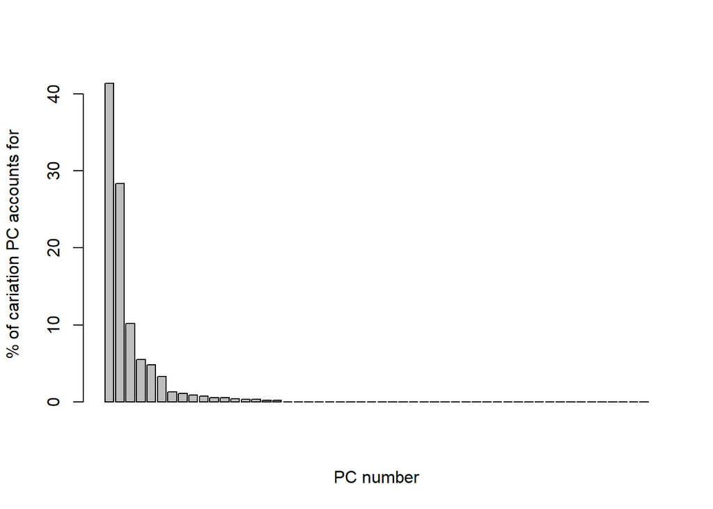

```r
pca <- prcomp(t(cur_table))
pc <- round(pca$sdev^2/sum(pca$sdev^2)*100,1)

barplot(pc, xlab = 'PC number', ylab = '% of cariation PC accounts for')
```

И точечный график по PC1 и PC2

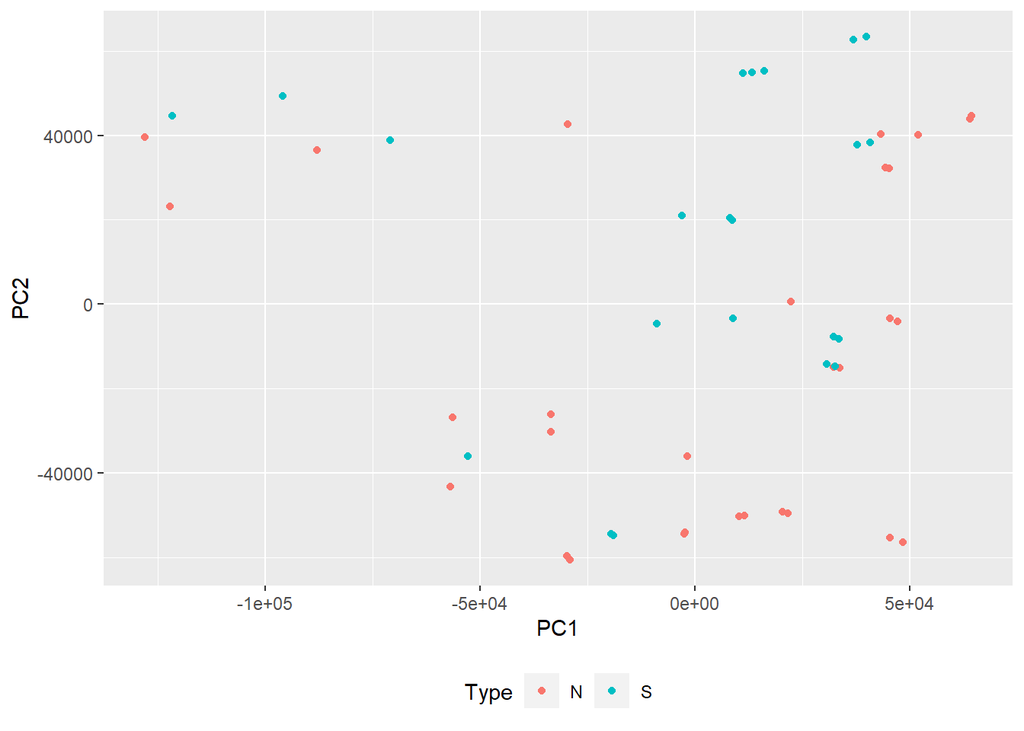

```r
pca.data <- data.frame(Type=cur_lables, PC1=pca$x[,1], PC2=pca$x[,2], PC3=pca$x[,3])
ggplot(pca.data, aes(x=PC1, y=PC2)) +
  geom_point(aes(col=Type)) +
  labs(x="PC1", y="PC2", col="Type") +
  theme(legend.position = "bottom")
```

И иерархическую кластеризацию по таблице текущих классов

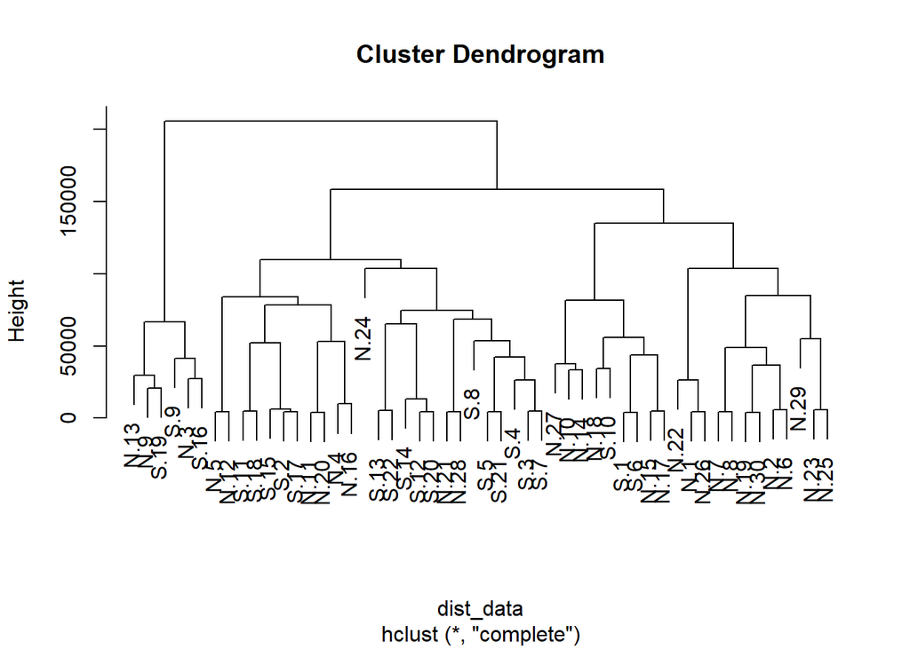

```r
dist_data <- dist(t(cur_table), method = "euclidean")
clust1 <-hclust(dist_data)
plot(clust1)
```

И MDSplot по таблице текущих классов (можно и по всей таблице каунтов, но это займёт много времени)

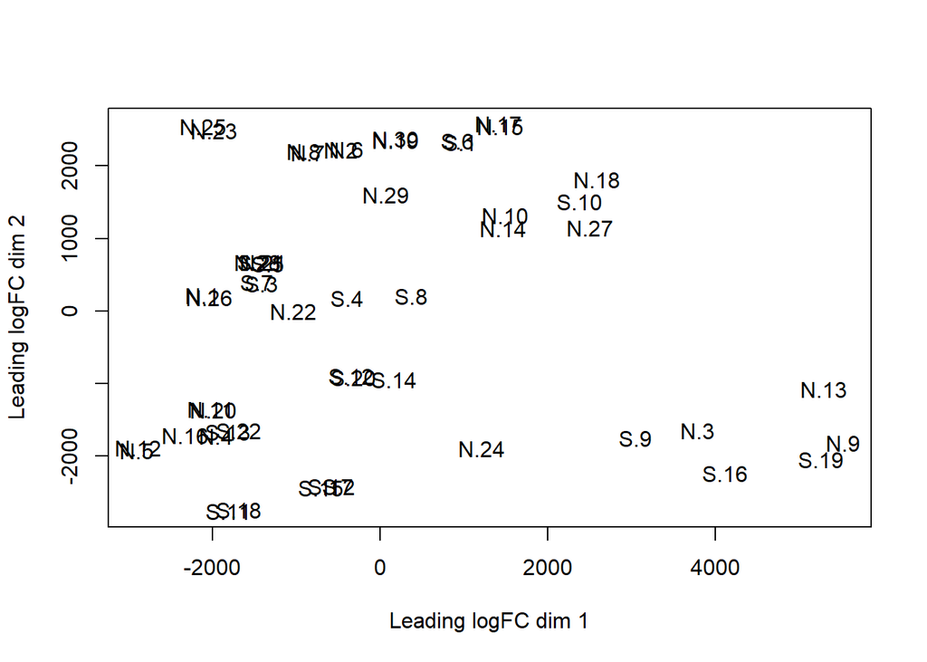

```r
plotMDS(cur_table)
```

```r
#plotMDS(counts_table)
```

Далее загрузим аннотацию из hsapiens_gene_ensembl

```r
mart <- useMart("ENSEMBL_MART_ENSEMBL")
#listDatasets(mart = mart)

mart <- useDataset("hsapiens_gene_ensembl", mart)
attributes <- c("ensembl_gene_id", "description", "chromosome_name",
                "start_position", "end_position", "gene_biotype",
                "strand", "hgnc_symbol", "entrezgene_id")

filters <- "ensembl_gene_id"
genes_annotation <- getBM(attributes = attributes, filters = filters, values = rownames(cur_table), mart = mart)
head(genes_annotation)
```

|  | ensembl_gene_id | description | chromosome_name | start_position | end_position | gene_biotype | strand | hgnc_symbol | entrezgene_id |
| --- | --- | --- | --- | --- | --- | --- | --- | --- | --- |
| 1 | ENSG00000000003 | tetraspanin 6 [Source:HGNC Symbol;Acc:HGNC:11858] | X | 100627108 | 100639991 | protein_coding | -1 | TSPAN6 | 7105 |
| 2 | ENSG00000000005 | tenomodulin [Source:HGNC Symbol;Acc:HGNC:17757] | X | 100584936 | 100599885 | protein_coding | 1 | TNMD | 64102 |
| 3 | ENSG00000000419 | dolichyl-phosphate mannosyltransferase subunit 1, catalytic [Source:HGNC Symbol;Acc:HGNC:3005] | 20 | 50934867 | 50958555 | protein_coding | -1 | DPM1 | 8813 |
| 4 | ENSG00000000457 | SCY1 like pseudokinase 3 [Source:HGNC Symbol;Acc:HGNC:19285] | 1 | 169849631 | 169894267 | protein_coding | -1 | SCYL3 | 57147 |
| 5 | ENSG00000000460 | chromosome 1 open reading frame 112 [Source:HGNC Symbol;Acc:HGNC:25565] | 1 | 169662007 | 169854080 | protein_coding | 1 | C1orf112 | 55732 |
| 6 | ENSG00000000938 | FGR proto-oncogene, Src family tyrosine kinase [Source:HGNC Symbol;Acc:HGNC:3697] | 1 | 27612064 | 27635185 | protein_coding | -1 | FGR | 2268 |

Проверяем количество генов и совпадения между таблицей текущих классов и аннотацией

```r
paste("In annotation: ", toString(length(genes_annotation$ensembl_gene_id)))
```

```
## [1] "In annotation:  58595"
```

```r
paste("In data: ", toString(length(rownames(cur_table))))
```

```
## [1] "In data:  58735"
```

```r
paste("Intersect: ", toString(length(intersect(rownames(cur_table), genes_annotation$ensembl_gene_id))))
```

```
## [1] "Intersect:  58444"
```

Судя по всему, эта база старая и не описывает все нужные нам гены. Выхода два: либо используем другой пакет (например: org.Hs.eg.db), либо довольствуемся тем, что есть, но проверяем в конце, не попали ли в топ результатов неаннотированные гены

Выберем второй вариант и подровняем таблицы, удалим дупликаты из аннотации (тк для функции необходимо совпадение размеров)

```r
cur_table_cut <- subset(cur_table, row.names(cur_table) %in% genes_annotation$ensembl_gene_id)
annotation_cut <- subset(genes_annotation, genes_annotation$ensembl_gene_id %in% row.names(cur_table_cut))
paste("In annotation after cut: ", toString(length(annotation_cut$ensembl_gene_id)))
```

```
## [1] "In annotation after cut:  58595"
```

```r
annotation_cut <- annotation_cut %>% distinct(ensembl_gene_id, .keep_all = TRUE)
paste("In annotation after drop dupl: ", toString(length(annotation_cut$ensembl_gene_id)))
```

```
## [1] "In annotation after drop dupl:  58444"
```

```r
paste("In data after cut: ", toString(length(rownames(cur_table_cut))))
```

```
## [1] "In data after cut:  58444"
```

Проведём анализ диф.экпрессии сначала без аннотации по полной таблице текущих классов

```r
# создание листа
DGE <- DGEList(counts = cur_table, group = cur_lables)

# нормализация методом TMM
DGE <- calcNormFactors(DGE, method = "TMM")

# дисперсия общая и по каждому гену
DGE <- estimateCommonDisp(DGE)
DGE <- estimateTagwiseDisp(DGE)

# тест на диф.экспрессию
DE_res <- exactTest(DGE)

DE_res_top_table <- topTags(DE_res)$table
DE_res_top_table
```

|  | logFC | logCPM | PValue | FDR |
| --- | --- | --- | --- | --- |
| ENSG00000285976 | 3.385777 | 2.8458409 | 3.364009e-83 | 1.975851e-78 |
| ENSG00000243449 | 4.062038 | 0.7358122 | 4.093274e-76 | 1.202092e-71 |
| ENSG00000102931 | 2.919822 | 1.3136195 | 6.049428e-68 | 1.184377e-63 |
| ENSG00000188483 | 2.333470 | 2.3334523 | 9.440994e-67 | 1.386292e-62 |
| ENSG00000141933 | 3.795001 | 0.2702141 | 2.221416e-49 | 2.308037e-45 |
| ENSG00000168282 | 4.441233 | 0.2706755 | 2.357746e-49 | 2.308037e-45 |
| ENSG00000101084 | 1.951124 | 2.3011217 | 4.090752e-49 | 3.432433e-45 |
| ENSG00000140406 | 1.249322 | 5.2770088 | 1.744112e-46 | 1.280505e-42 |
| ENSG00000107872 | 2.401879 | 1.9915327 | 1.499049e-45 | 9.782963e-42 |
| ENSG00000278922 | 3.500463 | 0.1577379 | 2.378648e-40 | 1.397099e-36 |

И то же самое с аннотацией по обрезанной таблице

```r
DGE_cut <- DGEList(counts = cur_table_cut, genes = annotation_cut, group = cur_lables)
DGE_cut <- calcNormFactors(DGE_cut, method = "TMM")
DGE_cut <- estimateCommonDisp(DGE_cut)
DGE_cut <- estimateTagwiseDisp(DGE_cut)
DE_res_cut <- exactTest(DGE_cut)

DE_res_top_table_cut <- topTags(DE_res_cut)$table
DE_res_top_table_cut
```

|  | ensembl_gene_id | description | chromosome_name | start_position | end_position | gene_biotype | strand | hgnc_symbol | entrezgene_id | logFC | logCPM | PValue | FDR |
| --- | --- | --- | --- | --- | --- | --- | --- | --- | --- | --- | --- | --- | --- |
| ENSG00000285976 | ENSG00000285976 | novel protein | 6 | 63572472 | 63583587 | protein_coding | 1 |  | NA | 3.385641 | 2.8459422 | 3.431904e-83 | 2.005742e-78 |
| ENSG00000243449 | ENSG00000243449 | chromosome 4 open reading frame 48 [Source:HGNC Symbol;Acc:HGNC:34437] | 4 | 2041993 | 2043970 | protein_coding | 1 | C4orf48 | 401115 | 4.061919 | 0.7359594 | 4.174403e-76 | 1.219844e-71 |
| ENSG00000102931 | ENSG00000102931 | ADP ribosylation factor like GTPase 2 binding protein [Source:HGNC Symbol;Acc:HGNC:17146] | 16 | 57245259 | 57253635 | protein_coding | 1 | ARL2BP | 23568 | 2.919690 | 1.3137569 | 6.048301e-68 | 1.178290e-63 |
| ENSG00000188483 | ENSG00000188483 | immediate early response 5 like [Source:HGNC Symbol;Acc:HGNC:23679] | 9 | 129175552 | 129178261 | protein_coding | -1 | IER5L | 389792 | 2.333338 | 2.3336045 | 1.021044e-66 | 1.491848e-62 |
| ENSG00000141933 | ENSG00000141933 | tubulin polyglutamylase complex subunit 1 [Source:HGNC Symbol;Acc:HGNC:25058] | 19 | 507497 | 519654 | protein_coding | 1 | TPGS1 | 91978 | 3.794875 | 0.2703689 | 2.287654e-49 | 2.372486e-45 |
| ENSG00000168282 | ENSG00000168282 | alpha-1,6-mannosyl-glycoprotein 2-beta-N-acetylglucosaminyltransferase [Source:HGNC Symbol;Acc:HGNC:7045] | 14 | 49620799 | 49623481 | protein_coding | 1 | MGAT2 | 4247 | 4.441125 | 0.2708495 | 2.435651e-49 | 2.372486e-45 |
| ENSG00000101084 | ENSG00000101084 | RAB5 interacting factor [Source:HGNC Symbol;Acc:HGNC:15870] | 20 | 36605779 | 36612557 | protein_coding | 1 | RAB5IF | 55969 | 1.950954 | 2.3012652 | 4.226438e-49 | 3.528714e-45 |
| ENSG00000140406 | ENSG00000140406 | talin rod domain containing 1 [Source:HGNC Symbol;Acc:HGNC:13519] | 15 | 81000923 | 81005788 | protein_coding | 1 | TLNRD1 | 59274 | 1.249159 | 5.2771329 | 1.744253e-46 | 1.274264e-42 |
| ENSG00000107872 | ENSG00000107872 | F-box and leucine rich repeat protein 15 [Source:HGNC Symbol;Acc:HGNC:28155] | 10 | 102419189 | 102423136 | protein_coding | 1 | FBXL15 | 79176 | 2.401716 | 1.9916630 | 1.536918e-45 | 9.980404e-42 |
| ENSG00000278922 | ENSG00000278922 | novel transcript | 16 | 30526918 | 30528294 | TEC | 1 |  | NA | 3.500324 | 0.1578795 | 2.333296e-40 | 1.363672e-36 |

Сравним топ-гены по анализу с аннотацией и без

```r
rownames(DE_res_top_table_cut) == rownames(DE_res_top_table)
```

```
##  [1] TRUE TRUE TRUE TRUE TRUE TRUE TRUE TRUE TRUE TRUE
```

Получились те же гены, значит, можно пользоваться результатами анализа с аннотацией Выведем их

```r
DE_res_top_table_cut
```

|  | ensembl_gene_id | description | chromosome_name | start_position | end_position | gene_biotype | strand | hgnc_symbol | entrezgene_id | logFC | logCPM | PValue | FDR |
| --- | --- | --- | --- | --- | --- | --- | --- | --- | --- | --- | --- | --- | --- |
| ENSG00000285976 | ENSG00000285976 | novel protein | 6 | 63572472 | 63583587 | protein_coding | 1 |  | NA | 3.385641 | 2.8459422 | 3.431904e-83 | 2.005742e-78 |
| ENSG00000243449 | ENSG00000243449 | chromosome 4 open reading frame 48 [Source:HGNC Symbol;Acc:HGNC:34437] | 4 | 2041993 | 2043970 | protein_coding | 1 | C4orf48 | 401115 | 4.061919 | 0.7359594 | 4.174403e-76 | 1.219844e-71 |
| ENSG00000102931 | ENSG00000102931 | ADP ribosylation factor like GTPase 2 binding protein [Source:HGNC Symbol;Acc:HGNC:17146] | 16 | 57245259 | 57253635 | protein_coding | 1 | ARL2BP | 23568 | 2.919690 | 1.3137569 | 6.048301e-68 | 1.178290e-63 |
| ENSG00000188483 | ENSG00000188483 | immediate early response 5 like [Source:HGNC Symbol;Acc:HGNC:23679] | 9 | 129175552 | 129178261 | protein_coding | -1 | IER5L | 389792 | 2.333338 | 2.3336045 | 1.021044e-66 | 1.491848e-62 |
| ENSG00000141933 | ENSG00000141933 | tubulin polyglutamylase complex subunit 1 [Source:HGNC Symbol;Acc:HGNC:25058] | 19 | 507497 | 519654 | protein_coding | 1 | TPGS1 | 91978 | 3.794875 | 0.2703689 | 2.287654e-49 | 2.372486e-45 |
| ENSG00000168282 | ENSG00000168282 | alpha-1,6-mannosyl-glycoprotein 2-beta-N-acetylglucosaminyltransferase [Source:HGNC Symbol;Acc:HGNC:7045] | 14 | 49620799 | 49623481 | protein_coding | 1 | MGAT2 | 4247 | 4.441125 | 0.2708495 | 2.435651e-49 | 2.372486e-45 |
| ENSG00000101084 | ENSG00000101084 | RAB5 interacting factor [Source:HGNC Symbol;Acc:HGNC:15870] | 20 | 36605779 | 36612557 | protein_coding | 1 | RAB5IF | 55969 | 1.950954 | 2.3012652 | 4.226438e-49 | 3.528714e-45 |
| ENSG00000140406 | ENSG00000140406 | talin rod domain containing 1 [Source:HGNC Symbol;Acc:HGNC:13519] | 15 | 81000923 | 81005788 | protein_coding | 1 | TLNRD1 | 59274 | 1.249159 | 5.2771329 | 1.744253e-46 | 1.274264e-42 |
| ENSG00000107872 | ENSG00000107872 | F-box and leucine rich repeat protein 15 [Source:HGNC Symbol;Acc:HGNC:28155] | 10 | 102419189 | 102423136 | protein_coding | 1 | FBXL15 | 79176 | 2.401716 | 1.9916630 | 1.536918e-45 | 9.980404e-42 |
| ENSG00000278922 | ENSG00000278922 | novel transcript | 16 | 30526918 | 30528294 | TEC | 1 |  | NA | 3.500324 | 0.1578795 | 2.333296e-40 | 1.363672e-36 |

Выведем топ по генной онтологии

```r
go <- goana.DGEExact(de=DE_res_cut, geneid = DE_res_cut$genes$entrezgene_id, species="Hs")
topGO(go,  sort="Up", number = 10)
```

|  | Term | Ont | N | Up | Down | P.Up | P.Down |
| --- | --- | --- | --- | --- | --- | --- | --- |
| GO:0005515 | protein binding | MF | 13514 | 1580 | 1231 | 3.464864e-98 | 1.125553e-84 |
| GO:0003674 | molecular_function | MF | 17945 | 1886 | 1517 | 5.102795e-98 | 3.427922e-125 |
| GO:0005488 | binding | MF | 16124 | 1764 | 1382 | 4.457932e-96 | 5.506290e-90 |
| GO:0005622 | intracellular | CC | 14811 | 1649 | 1397 | 5.262044e-86 | 1.249214e-139 |
| GO:0005575 | cellular_component | CC | 18782 | 1895 | 1535 | 2.624197e-75 | 2.085052e-113 |
| GO:0110165 | cellular anatomical entity | CC | 18592 | 1880 | 1526 | 9.684866e-74 | 5.961478e-112 |
| GO:0043229 | intracellular organelle | CC | 13033 | 1459 | 1244 | 4.024923e-65 | 6.197756e-105 |
| GO:0043226 | organelle | CC | 14126 | 1543 | 1342 | 1.334359e-64 | 1.476937e-126 |
| GO:0043227 | membrane-bounded organelle | CC | 13013 | 1444 | 1288 | 1.556445e-60 | 2.238483e-130 |
| GO:0005737 | cytoplasm | CC | 11493 | 1316 | 1190 | 3.333863e-59 | 7.997547e-125 |